# Exercise #3

Fortgeschrittene Statistische Software für NF

Anastasiia Petrus (12521274), Nils Przybylla (12734986)  
2025-06-06

## Exercise 1: Initializing git (4 Points)

For this whole exercise sheet we will be tracking all our changes to it in git.

1. Start by initializing a new R project with git support, called `2025-exeRcise-sheet-3`. If you forgot how to do this, you can follow this [guide](https://malikaihle.github.io/Introduction-RStudio-Git-GitHub/rstudio_project.html).
2. Commit the files generated by Rstudio.
3. For all of the following tasks in this exercise sheet we ask you to always commit your changes after finishing each subtask e.g. create a commit after task *1d*, *1e* etc.

> Note: This applies only to answers that have text or code as their answer. If you complete tasks in a different order or forget to commit one, this is no problem. If you change your answers you can just create multiple commits to track the changes.
4. Name 2 strengths and 2 weaknesses of git. (Don’t forget to create a commit after this answer, see *1c*)

   **Strengths:**
   1. History allows you to go back and understand changes or revert when there are problems
   2. Great for collaboration

   **Weaknesses:**
   1. Can be a bit complicated to use
   2. Struggles with binary (i.e. non-text) files
5. Knit this exercise sheet. Some new files will automatically be generated when knitting the sheet e.g. the HTML page. Ignore these files, as we only want to track the source files themselves. You can, but don’t need to create a `.gitignore` file. Just do not commit these files manually.

## Exercise 2: Putting your Repository on GitHub (3 Points)

For this task you will upload your solution to GitHub.

1. Create a new repository on GitHub in your account named `exeRcise-sheet-3`. Make sure you create a **public repository** so we are able to see it for grading. Add the link to the repository below: https://github.com/nilz1989/exeRcise-sheet-3.git
2. Push your code to this new repository by copying and executing the snippet on github listed under `…or push an existing repository from the command line`.
3. Regularly push your latest changes to GitHub again and especially do so when you are finished with this sheet.

## Exercise 3: Pixar Films (4 Points)

Download the `pixar_films` and `public_response` datasets from the GitHub repository and track them in git.

Link: https://github.com/rfordatascience/tidytuesday/tree/main/data/2025/2025-03-11

For small datasets like these adding them to git is not a problem.

1. Load the `pixar_films` dataset into R. Clean the dataset by removing films without a title. Inspect the variable `film_rating`. What are the possible values and what do they mean? Create a factor variable for the film rating. Why is this appropriate?

```r
library(ggplot2)
library(readr)
library(dplyr)

pixar_films <- read_csv("pixar_films.csv")
```

```r
pixar_films_clean <- pixar_films %>% filter(!is.na(film) & film != "")
print(head(pixar_films_clean, 10))
```

```
# A tibble: 10 × 5
   number film            release_date run_time film_rating
    <dbl> <chr>           <date>          <dbl> <chr>
 1      1 Toy Story       1995-11-22         81 G
 2      2 A Bug's Life    1998-11-25         95 G
 3      3 Toy Story 2     1999-11-24         92 G
 4      4 Monsters, Inc.  2001-11-02         92 G
 5      5 Finding Nemo    2003-05-30        100 G
 6      6 The Incredibles 2004-11-05        115 PG
 7      7 Cars            2006-06-09        117 G
 8      8 Ratatouille     2007-06-29        111 G
 9      9 WALL-E          2008-06-27         98 G
10     10 Up              2009-05-29         96 PG
```

From the dataset, we observe the following values:

“G”: General audiences — all ages admitted.

“PG”: Parental Guidance Suggested — some material may not be suitable for children.

“N/A” or NA: Missing or unavailable rating (e.g., for very recent or unreleased films like Lightyear or Turning Red).

```r
pixar_films_clean <- pixar_films_clean %>%
  mutate(film_rating_factor = factor(film_rating))

pixar_films_new <- pixar_films_clean %>%
  select(-film_rating)
```

Creating a factor is appropriate because:

1. Categorical nature: Film ratings are categories (e.g., “G”, “PG”) and not continuous or numeric values.
2. Useful for analysis: Factors are treated properly in statistical models (e.g. regression) or in group-wise summaries (like counting how many films per rating)
3. Ensures ordering if needed: We can specify levels to reflect an order (e.g., “G” < “PG”), if appropriate for some tasks.
2. Inspect the film titles manually. Which films form a film series? A film series can be identified by a common word in the titles of the films, often in conjunction with a number in the title, e.g. “Despicable Me” and “Despicable Me 2”. Create a dataframe which displays a list of the different series with the titles of the films and how many films belong to the series. Output the dataframe.

```r
library(stringr)
library(dplyr)

film_series_alternative <- pixar_films_clean %>%
  mutate(series = case_when(
    (str_detect(film, regex("Toy|Story"))) ~ "Toy Story",
    (str_detect(film, regex("Cars"))) ~ "Cars",
    (str_detect(film, regex("Monsters"))) ~ "Monsters",
    (str_detect(film, regex("Incredibles"))) ~ "Incredibles",
    (str_detect(film, regex("Finding|Nemo|Dory"))) ~ "Finding",

    TRUE ~ film
  ))

film_series_summary_alternative <- film_series_alternative %>%
  group_by(series) %>%
  summarise(
    titles = paste(film, collapse = ", "),
    count = n(),
    .groups = "drop"
  ) %>% filter(count >= 2)

print(head(film_series_summary_alternative, 10))
```

```
# A tibble: 5 × 3
  series      titles                                           count
  <chr>       <chr>                                            <int>
1 Cars        Cars, Cars 2, Cars 3                                 3
2 Finding     Finding Nemo, Finding Dory                           2
3 Incredibles The Incredibles, Incredibles 2                       2
4 Monsters    Monsters, Inc., Monsters University                  2
5 Toy Story   Toy Story, Toy Story 2, Toy Story 3, Toy Story 4     4
```

3. Load the `public_response` dataframe into R. Convert the `cinema_score` variable into a factor while ensuring the factor levels are defined in ascending order, from the lowest to the highest score. Combine `public_response` with the `pixar_films` dataset using an appropriate merge variable.

```r
library(readr)
library(dplyr)

public_response <- read_csv("public_response.csv")
```

```r
public_response$cinema_score <- factor(
  public_response$cinema_score,
  levels = c("A–", "A", "A+"),
  ordered = TRUE
)
```

```r
library(dplyr)

pixar_combined <- left_join(pixar_films_new, public_response, by = "film")
print(head(pixar_combined, 10))
```

```
# A tibble: 10 × 9
   number film            release_date run_time film_rating_factor
    <dbl> <chr>           <date>          <dbl> <fct>
 1      1 Toy Story       1995-11-22         81 G
 2      2 A Bug's Life    1998-11-25         95 G
 3      3 Toy Story 2     1999-11-24         92 G
 4      4 Monsters, Inc.  2001-11-02         92 G
 5      5 Finding Nemo    2003-05-30        100 G
 6      6 The Incredibles 2004-11-05        115 PG
 7      7 Cars            2006-06-09        117 G
 8      8 Ratatouille     2007-06-29        111 G
 9      9 WALL-E          2008-06-27         98 G
10     10 Up              2009-05-29         96 PG
# ℹ 4 more variables: rotten_tomatoes <dbl>, metacritic <dbl>,
#   cinema_score <ord>, critics_choice <dbl>
```

4. Choose one of the variables representing the public response and create a bar plot for the films belonging to a series. Here are the details of the plot:
   - The film series are represented on the x-axis.
   - Your chosen public response variable is displayed on the y-axis.
   - Each film in the series is represented as a separate bar. Bars are grouped by film under their respective series on the x-axis. Order the bars within a series according to the release date of the films.
   - A title and axis labels for context.

   What do you notice when comparing the scores of the films in a series? Do you see any patterns?

We’ll use rotten_tomatoes because it provides a numeric score for the majority of films.

install.packages(“viridis”)

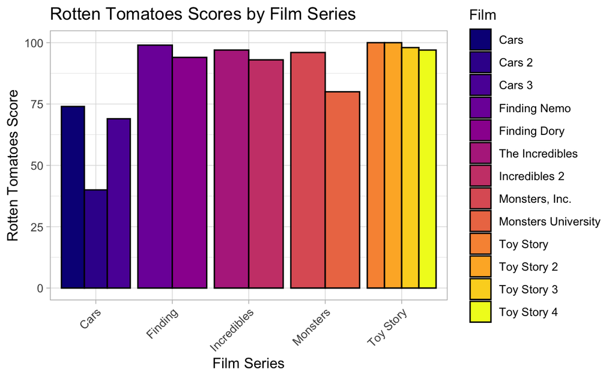

```r
filtered_series_data <- film_series_alternative %>%
  semi_join(film_series_summary_alternative, by = "series")

series_scores_ordered_alternative <- pixar_combined %>%
  inner_join(filtered_series_data %>%
  select(film, series), by = "film") %>%
  arrange(series, release_date) %>%
  mutate(film = factor(film, levels = unique(film)))

ggplot(series_scores_ordered_alternative, aes(
  x = series,
  y = rotten_tomatoes,
  fill = film
)) +
  geom_bar(
    stat = "identity",
    position = position_dodge(),
    color = "black"
  ) +
  labs(
    title = "Rotten Tomatoes Scores by Film Series",
    x = "Film Series",
    y = "Rotten Tomatoes Score",
    fill = "Film"
  ) +
  scale_fill_viridis_d(option = "C") +
  theme_light() +
  theme(
    axis.text.x = element_text(angle = 45, hjust = 1)
  )
```

Cars shows a decline in reception (Cars 2 scored especially low).

Finding Nemo vs Finding Dory – both are well received, but original tends to score slightly higher.

Incredibles has strong and consistent ratings across both films.

Toy Story scores remain consistently high across the series (often 97–100).

Many Pixar originals tend to outperform sequels (like the Monsters movies), except for franchises like Toy Story that maintain quality.

## Exercise 4: Open Analysis (4 points)

This exercise is a bit more open-ended. You can choose any dataset from [Our World in Data](https://ourworldindata.org/) and analyze it, while determining the research question yourself.

1. Go to https://github.com/owid/owid-datasets/tree/master/datasets and choose a dataset that interests you. You can have a look at https://ourworldindata.org/ to gather some inspiration.
2. Download the dataset and track it in git.
3. Put the name / title of the dataset and a link to it below.
- Dataset Name: **Food waste in the European Union - Europa (2010)**
- Link: https://github.com/owid/owid-datasets/tree/master/datasets/Food%20waste%20in%20the%20European%20Union%20-%20Europa%20(2010)#food-waste-in-the-european-union—europa-2010
4. Come up with a (research) question you want to answer with the data and briefly explain why you believe this is an interesting question within one sentence. It should be a question that can be answered with the dataset and using R.

Which European countries rank highest in food waste by sector (Manufacturing, Households, Other), and how do these rankings differ across sectors?”

Why this question is interesting:

It allows us to identify whether specific sectors are more responsible for food waste in different countries.

Sector-specific insights can help guide targeted policy interventions (e.g., encouraging more sustainable household behavior or improving manufacturing efficiency).

Comparing sectoral rankings can reveal structural or cultural differences in food systems between countries.

5. Use R to answer your chosen question. Please limit your analysis to the functions and techniques we have covered so far in the course. You are **not expected** to use advanced statistical models or external packages which haven’t been introduced.

```r
library(tidyverse)

food_waste <- read_csv("Food_waste_in_the_European_Union_2010.csv")

food_waste_clean <- food_waste %>%
  filter(Entity != "European Union")

food_waste_long <- food_waste_clean %>%
  pivot_longer(cols = c(`Manufacturing (Europa (2010))`,
                        `Households (Europa (2010))`,
                        `Other (Europa (2010))`),
               names_to = "Sector", values_to = "Food_waste_tonnes")

food_waste_long <- food_waste_long %>%
  mutate(Sector = case_when(
    str_detect(Sector, "Manufacturing") ~ "Manufacturing",
    str_detect(Sector, "Households") ~ "Households",
    str_detect(Sector, "Other") ~ "Other"
  ))

top10_total <- food_waste_long %>%
  group_by(Entity) %>%
  summarise(total_waste = sum(Food_waste_tonnes, na.rm = TRUE)) %>%
  slice_max(total_waste, n=10) %>%
  pull(Entity)

top10_overall_df <- food_waste_long %>%
  filter(Entity %in% top10_total)
```

6. Create a meaningful plot / figure with the dataset. Make sure to provide a figure caption (via the chunk options / Rmarkdown) and correctly label the figure.

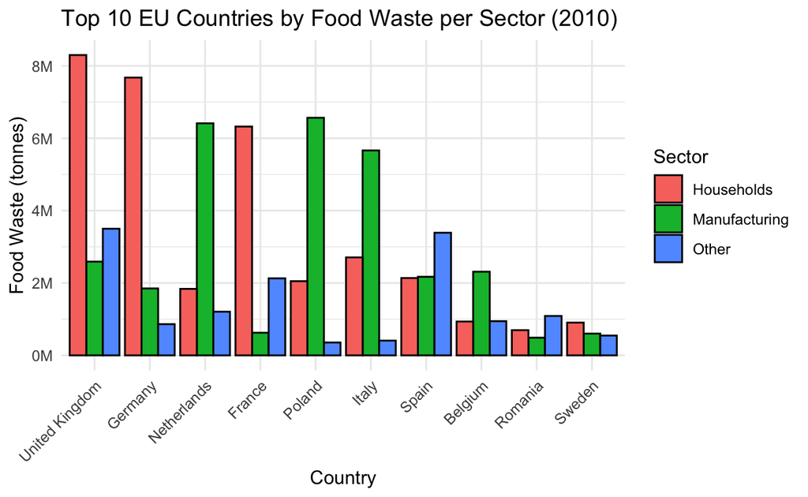

```r
library(scales)

ggplot(top10_overall_df, aes(x = reorder(Entity, -Food_waste_tonnes),
                              y = Food_waste_tonnes, fill = Sector)) +
  geom_col(position = "dodge", color = "black") +
  scale_y_continuous(labels = label_number(scale = 1e-6, suffix = "M")) +
  labs(title = "Top 10 EU Countries by Food Waste per Sector (2010)",
       x = "Country",
       y = "Food Waste (tonnes)",
       fill = "Sector") +
  theme_minimal() +
  theme(axis.text.x = element_text(angle = 45, hjust = 1)
)
```

General observations:

The United Kingdom is the top contributor to total food waste, with particularly high waist levels in the household sector.

Countries like Poland, Italy, and the Netherlands show especially high waisted in the manufacturing sector.

Spain stands out for having a relatively large contribution from the other category, compared to most other countries.

Belgium, Romania, and Sweden round out the top 10 with overall lower waist levels, but still notable.

Sectoral trends:

The manufacturing sector rank second overall, but leads in countries like Poland, the Netherlands and Italy.

The other category typically contributes the least though countries like Spain and the UK show notable values here as well.

Key takeaways:

Household behavior plays a dominant role in food waste generation across Europe

The industrial footprint of countries influences the proportion of waste from manufacturing.

Sector-specific differences suggest the need for tailored food, waste reduction strategies for each country.

## Final Note

Make sure to push all your commits and changes to GitHub before submitting the exercise sheet.